# Kaggle Facial Points Detection: Univ of Montreal: left_eye_center classification:: Faces_patch_clssfr_Pcos

## Step `10.0: predict data new`

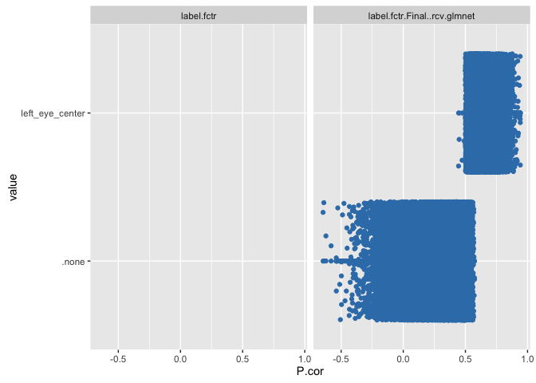

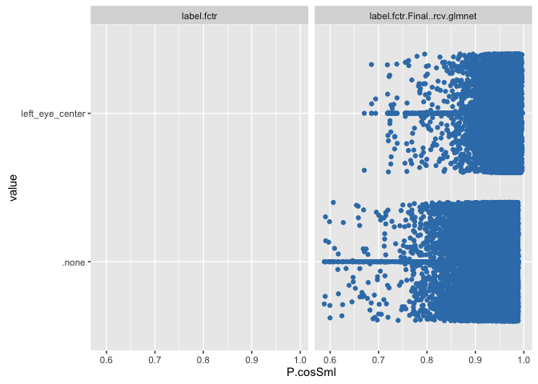

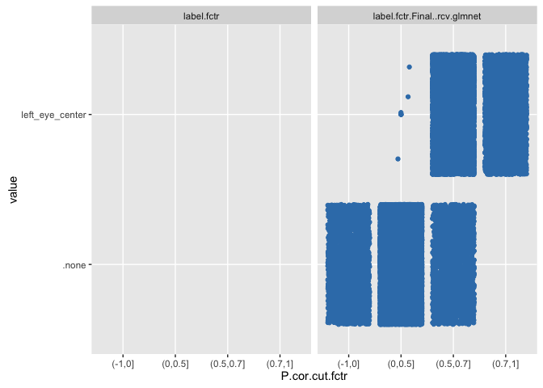

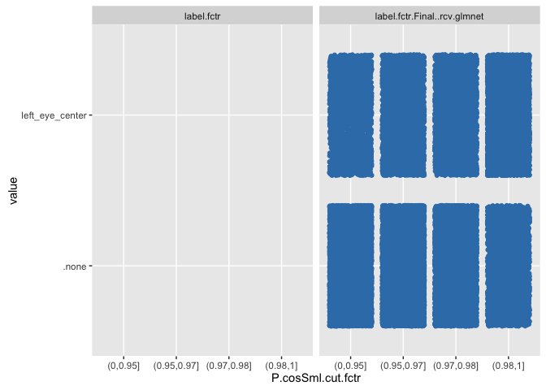

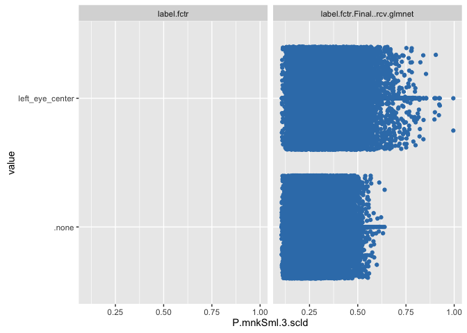

[output not shown]

[output cut: 96 more lines]

[output not shown]

```
## [1] 0.2
```

```
## [1] "glb_sel_mdl_id: All.X##rcv#glmnet"
```